# Test Novel Object Analysis

Alexa & Viktoria & Adam

December 10th, 2018

Load libraries

```r
# tidyverse includes the packages readr, dplyr, ggPlot ... etc.
library(tidyverse)

# ggbeeswarm includes geom_beeswarm()
library(ggbeeswarm)

# broom includes tidy()
library(broom)
```

## Read in the raw data

Read in the novel object test raw data (**Analysis Output-VA Novel Object.csv**):

```r
# Import novel object data
novelObjectRaw <- read_csv("Analysis Output-VA Novel Object.csv", skip = 4,
                            col_names = header)
# Look at Novel Object data
novelObjectRaw
```

```
## # A tibble: 40 x 13
##    `Object Type` `Trial # NO` `Trial # OF` `Novel Object` `Familiar Objec~
##    <chr>                <dbl>        <dbl> <chr>          <chr>
##  1 Familiar                 1            1 object 1       object 2
##  2 Familiar                 2            2 object 1       object 2
##  3 Familiar                 3            3 object 1       object 2
##  4 Familiar                 4            4 object 1       object 2
##  5 Novel                    5            1 object 1       object 2
##  6 Novel                    6            2 object 1       object 2
##  7 Novel                    7            3 object 1       object 2
##  8 Novel                    8            4 object 1       object 2
##  9 Familiar                 9            5 object 1       object 2
## 10 Familiar                10            6 object 1       object 2
## # ... with 30 more rows, and 8 more variables: `Distance to objects:object
## #   1/Nose-point:Mean` <dbl>, `Distance to objects:object
## #   2/Nose-point:Mean` <dbl>, `Nose touching objects:object
## #   1/Nose-point:Duration` <dbl>, `Nose touching objects:object
## #   1/Nose-point:Frequency` <dbl>, `Nose touching objects:object
## #   1/Nose-point:Latency to first` <dbl>, `Nose touching objects:object
## #   2/Nose-point:Duration` <dbl>, `Nose touching objects:object
## #   2/Nose-point:Frequency` <dbl>, `Nose touching objects:object
## #   2/Nose-point:Latency to first` <dbl>
```

Read in the data containing the treatment and sex information for each animal (**Injections Data.csv**):

```r
# Import injections data
injectionsDataRaw <- read_csv("Injections Data.csv", n_max = 20)

# Take a look at the injections data
injectionsDataRaw
```

```
## # A tibble: 20 x 29
##    Treatment Sex   Tag   `12-Oct` `13-Oct` `14-Oct` `15-Oct` `16-Oct`
##        <dbl> <chr> <chr>    <dbl>    <dbl>    <dbl>    <dbl>    <dbl>
##  1         0 F     1L          25       27       31       34       36
##  2         1 M     2L          27       29       33       37       36
##  3         0 M     3L          25       27       31       33       34
##  4         1 F     1R          23       24       28       30       33
##  5         0 M     2R          25       27       31       34       35
##  6         1 F     3R          21       23       25       27       30
##  7         0 M     1L-1R       27       30       34       36       37
##  8         1 M     1L-2R       28       29       32       36       38
##  9         0 F     2L-2R       26       27       31       33       35
## 10         1 F     2L-1R       27       28       31       34       36
## 11         0 F     1L          21       25       27       31       32
## 12         1 F     2L          23       25       28       30       33
## 13         0 M     3L          23       27       30       32       36
## 14         1 M     1R          24       26       28       32       34
## 15         0 M     2L-1R       23       26       28       31       33
## 16         1 M     3R          24       27       30       33       36
## 17         0 M     1L-1R       25       27       30       33       35
## 18         1 F     1L-2R       22       25       27       30       32
## 19         0 F     2L-2R       23       26       29       31       35
## 20         1 F     2R          23       26       29       30       33
## # ... with 21 more variables: `17-Oct` <dbl>, `18-Oct` <dbl>,
## #   `19-Oct` <dbl>, `20-Oct` <dbl>, `21-Oct` <dbl>, `22-Oct` <dbl>,
## #   `23-Oct` <dbl>, `24-Oct` <dbl>, `25-Oct` <dbl>, `26-Oct` <dbl>,
## #   `27-Oct` <dbl>, `28-Oct` <dbl>, `29-Oct` <dbl>, `30-Oct` <dbl>,
## #   `31-Oct` <dbl>, `Parent Cage #` <dbl>, `Current Cage #` <dbl>, `Trial
## #   # Open Field` <dbl>, `Trial # Familiar Object` <dbl>, `Trial # Novel
## #   Object` <dbl>, Comments <chr>
```

Read in a table that maps treatment numbers to treatment strings

```r
# Create a dictionary for Treatment
treatmentTypeTable <- read_csv("Treatment Dictionary.csv")

# Display the table
treatmentTypeTable
```

```
## # A tibble: 2 x 2
##   Treatment TreatmentStr
##       <dbl> <chr>
## 1         0 Control
## 2         1 Ethosuximide
```

## Combine and rearrange the data

```r
# Rearrange the data
novelObjectExpanded <-
    novelObjectRaw %>%
    full_join(injectionsDataRaw, by = c("Trial # OF" = "Trial # Open Field")) %>%
    full_join(treatmentTypeTable, by = "Treatment") %>%
    mutate(DurationObject1 = `Nose touching objects:object 1/Nose-point:Duration`) %>%
    mutate(DurationObject2 = `Nose touching objects:object 2/Nose-point:Duration`) %>%
    mutate(Sex = factor(Sex)) %>%
    mutate(TreatmentStr = factor(TreatmentStr)) %>%
    mutate(TrialType = factor(`Object Type`)) %>%
    mutate(DurationObjectRatio = DurationObject1 / DurationObject2) %>%
    mutate(DiscriminationIndex = (DurationObject1 - DurationObject2) / (DurationObject1 + DurationObject2)) %>%
    mutate(TrialTypeTreatment = interaction(TreatmentStr, TrialType, sep = "-"))

# Take a glimpse of all the variables in the data
glimpse(novelObjectExpanded)
```

```
## Observations: 40
## Variables: 48
## $ `Object Type`                                                <chr> "...
## $ `Trial # NO`                                                 <dbl> 1...
## $ `Trial # OF`                                                 <dbl> 1...
## $ `Novel Object`                                               <chr> "...
## $ `Familiar Object`                                            <chr> "...
## $ `Distance to objects:object 1/Nose-point:Mean`               <dbl> 2...
## $ `Distance to objects:object 2/Nose-point:Mean`               <dbl> 2...
## $ `Nose touching objects:object 1/Nose-point:Duration`         <dbl> 1...
## $ `Nose touching objects:object 1/Nose-point:Frequency`        <dbl> 2...
## $ `Nose touching objects:object 1/Nose-point:Latency to first` <dbl> 6...
## $ `Nose touching objects:object 2/Nose-point:Duration`         <dbl> 2...
## $ `Nose touching objects:object 2/Nose-point:Frequency`        <dbl> 3...
## $ `Nose touching objects:object 2/Nose-point:Latency to first` <dbl> 1...
```

[output cut: 35 more lines]

Remove the first animal because it was used as a test animal:

```r
# Select all but the first row
novelObjectFiltered <-
    novelObjectExpanded %>%
    slice(2:n())

# Take a look at the data with rows filtered
novelObjectFiltered
```

```
## # A tibble: 39 x 48
##    `Object Type` `Trial # NO` `Trial # OF` `Novel Object` `Familiar Objec~
##    <chr>                <dbl>        <dbl> <chr>          <chr>
##  1 Familiar                 2            2 object 1       object 2
##  2 Familiar                 3            3 object 1       object 2
##  3 Familiar                 4            4 object 1       object 2
##  4 Novel                    5            1 object 1       object 2
##  5 Novel                    6            2 object 1       object 2
##  6 Novel                    7            3 object 1       object 2
##  7 Novel                    8            4 object 1       object 2
##  8 Familiar                 9            5 object 1       object 2
##  9 Familiar                10            6 object 1       object 2
## 10 Familiar                11            7 object 1       object 2
## # ... with 29 more rows, and 43 more variables: `Distance to
## #   objects:object 1/Nose-point:Mean` <dbl>, `Distance to objects:object
## #   2/Nose-point:Mean` <dbl>, `Nose touching objects:object
## #   1/Nose-point:Duration` <dbl>, `Nose touching objects:object
## #   1/Nose-point:Frequency` <dbl>, `Nose touching objects:object
## #   1/Nose-point:Latency to first` <dbl>, `Nose touching objects:object
## #   2/Nose-point:Duration` <dbl>, `Nose touching objects:object
## #   2/Nose-point:Frequency` <dbl>, `Nose touching objects:object
## #   2/Nose-point:Latency to first` <dbl>, Treatment <dbl>, Sex <fct>,
## #   Tag <chr>, `12-Oct` <dbl>, `13-Oct` <dbl>, `14-Oct` <dbl>,
## #   `15-Oct` <dbl>, `16-Oct` <dbl>, `17-Oct` <dbl>, `18-Oct` <dbl>,
## #   `19-Oct` <dbl>, `20-Oct` <dbl>, `21-Oct` <dbl>, `22-Oct` <dbl>,
## #   `23-Oct` <dbl>, `24-Oct` <dbl>, `25-Oct` <dbl>, `26-Oct` <dbl>,
## #   `27-Oct` <dbl>, `28-Oct` <dbl>, `29-Oct` <dbl>, `30-Oct` <dbl>,
## #   `31-Oct` <dbl>, `Parent Cage #` <dbl>, `Current Cage #` <dbl>, `Trial
## #   # Familiar Object` <dbl>, `Trial # Novel Object` <dbl>,
## #   Comments <chr>, TreatmentStr <fct>, DurationObject1 <dbl>,
## #   DurationObject2 <dbl>, TrialType <fct>, DurationObjectRatio <dbl>,
## #   DiscriminationIndex <dbl>, TrialTypeTreatment <fct>
```

Select only the variables that will be analyzed:

```r
# Select variables that will be analyzed
novelObjectData <-
    novelObjectFiltered %>%
    select(TrialType, Treatment = TreatmentStr, Sex,
           DurationObject1, DurationObject2, DurationObjectRatio, DiscriminationIndex, Tag, TrialTypeTreatment)

# Take a look at the data with columns filtered
novelObjectData
```

```
## # A tibble: 39 x 9
##    TrialType Treatment Sex   DurationObject1 DurationObject2
##    <fct>     <fct>     <fct>           <dbl>           <dbl>
##  1 Familiar  Control   F                40.2            37.0
##  2 Familiar  Ethosuxi~ F                28.0            36.2
##  3 Familiar  Control   M                14.6            23.8
##  4 Novel     Control   F                48.0            28.8
##  5 Novel     Control   F                44.8            20.4
##  6 Novel     Ethosuxi~ F                52.9            25.4
##  7 Novel     Control   M                48.8            24.2
##  8 Familiar  Control   M                40.4            20.2
##  9 Familiar  Ethosuxi~ F                51.9            33.8
## 10 Familiar  Ethosuxi~ F                64.9            54.1
## # ... with 29 more rows, and 4 more variables: DurationObjectRatio <dbl>,
## #   DiscriminationIndex <dbl>, Tag <chr>, TrialTypeTreatment <fct>
```

## Make plots

#### Use the Duration Object Ratio (Duration at Object 1 / Duration at Object 2)

Plot the Duration Object Ratio versus Trial Type as a box plot, colored by Treatment

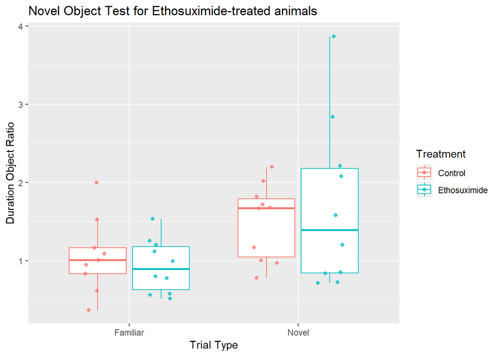

```r
# Add the data to the canvas
durationRatioPlot <-
    ggplot(novelObjectData, aes(TrialType, DurationObjectRatio, color = Treatment)) +
    labs(x = "Trial Type", y = "Duration Object Ratio",
         title = "Novel Object Test for Ethosuximide-treated animals")

# Plot as a combination of jitter and box plot
durationRatioPlot + geom_boxplot(outlier.alpha = 0) +
    geom_point(alpha = 0.75, position = position_jitterdodge(jitter.width = 0.3))
```

```r
# Save the plot
ggsave("novelObject_durationObjectRatio_boxplot_jitter.png")
```

Plot the Duration Object Ratio versus Trial Type as a violin plot

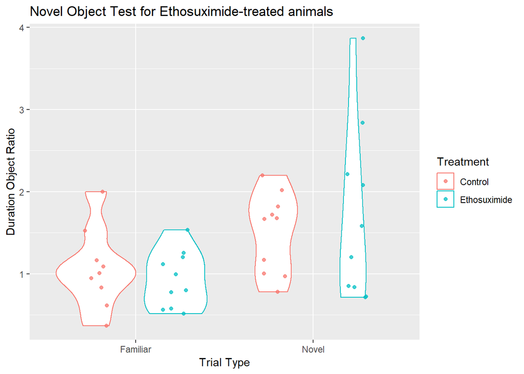

```r
# Plot as a combination of jitter and violin plot
durationRatioPlot + geom_violin() +
    geom_point(alpha = 0.75, position = position_jitterdodge(jitter.width = 0.3, dodge.width = 0.9))
```

```r
# Save the plot
ggsave("novelObject_durationObjectRatio_violin_jitter.png")
```

Plot the Duration Object Ratio versus Trial Type as a beeswarm plot

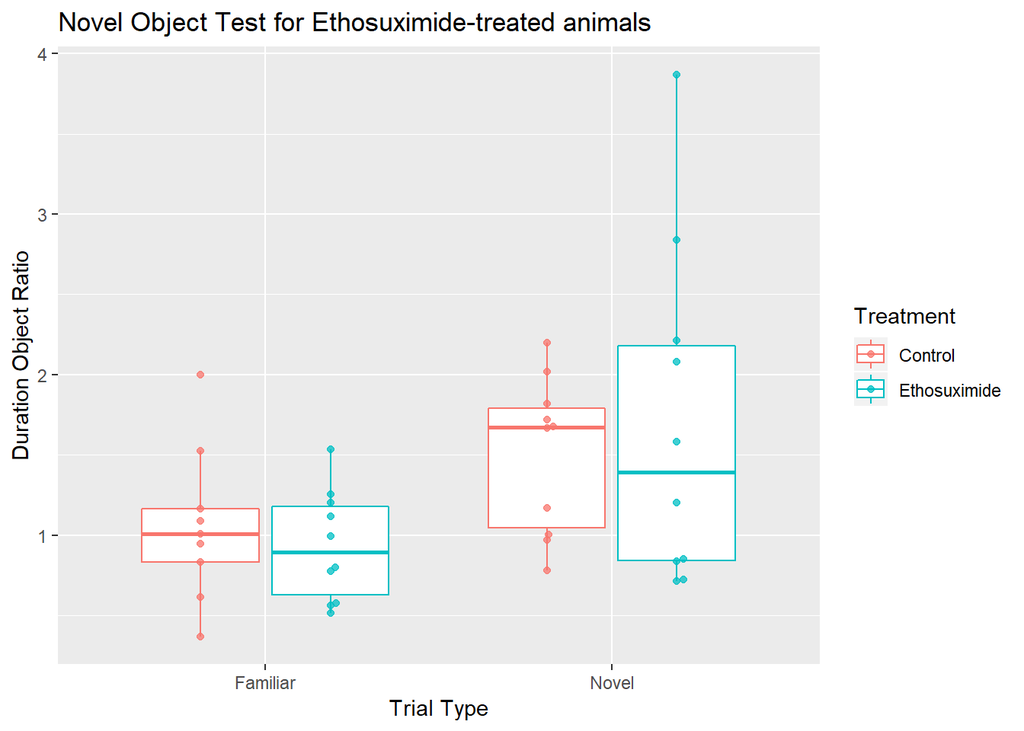

```r
# Plot as a combination of beeswarm and box plot
durationRatioPlot + geom_boxplot(outlier.alpha = 0) +
    geom_beeswarm(alpha = 0.75, dodge.width = 0.75)
```

```r
# Save the plot
ggsave("novelObject_durationObjectRatio_boxplot_beeswarm.png")
```

#### Use Discrimination Index (duration at object 1 - duration at object 2 / (duration at object 1 + duration at object 2)

Plot the Discrimination Index versus Trial Type as a box plot, colored by Treatment

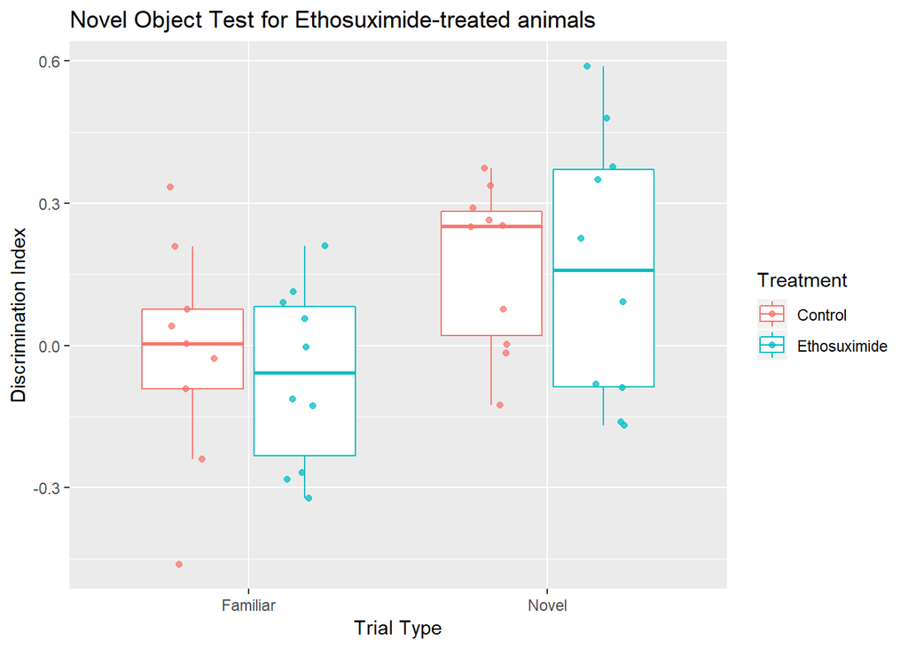

```r
# Add the data to the canvas
discriminationIndexPlot <-
    ggplot(novelObjectData, aes(TrialType, DiscriminationIndex, color = Treatment)) +
    labs(x = "Trial Type", y = "Discrimination Index",
         title = "Novel Object Test for Ethosuximide-treated animals")

# Plot as a combination of jitter and box plot
discriminationIndexPlot + geom_boxplot(outlier.alpha = 0) +
    geom_point(alpha = 0.75, position = position_jitterdodge(jitter.width = 0.3))
```

```r
# Save the plot
ggsave("novelObject_discriminationIndex_boxplot_jitter.png")
```

Plot the Discrimination Index versus Trial Type as a violin plot

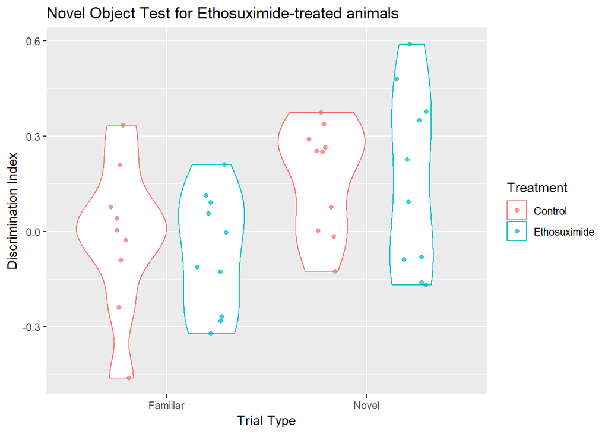

```r
# Plot as a combination of jitter and violin plot
discriminationIndexPlot + geom_violin() +
    geom_point(alpha = 0.75, position = position_jitterdodge(jitter.width = 0.3, dodge.width = 0.9))
```

```r
# Save the plot
ggsave("novelObject_discriminationIndex_violin_jitter.png")
```

Plot the Discrimination Index versus Trial Type as a beeswarm plot

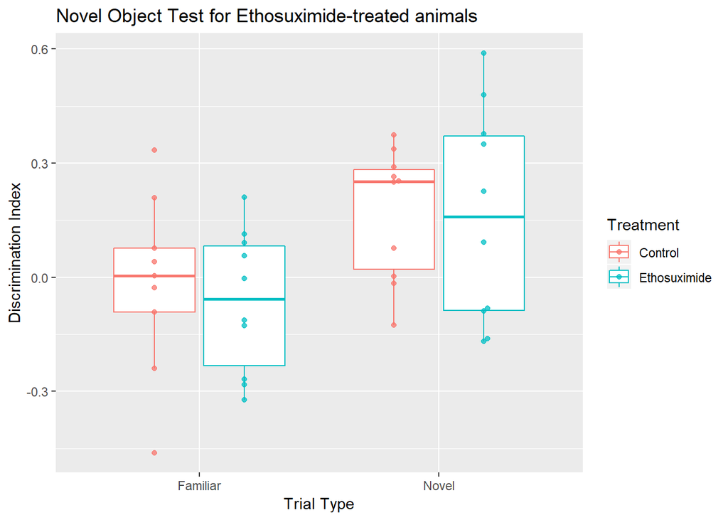

```r
# Plot as a combination of beeswarm and box plot
discriminationIndexPlot + geom_boxplot(outlier.alpha = 0) +
    geom_beeswarm(alpha = 0.75, dodge.width = 0.75)
```

```r
# Save the plot
ggsave("novelObject_discriminationIndex_boxplot_beeswarm.png")
```

## Perform statistics

#### Use the Duration Object Ratio (Duration at Object 1 / Duration at Object 2)

Use the Shapiro-Wilk test to test for normality

```r
# Test the entire data set for normality
shapiro.test(novelObjectData$DurationObjectRatio)
```

```
##
##  Shapiro-Wilk normality test
##
## data:  novelObjectData$DurationObjectRatio
## W = 0.87647, p-value = 0.000499
```

```r
# Test each data set for normality
tapply(novelObjectData$DurationObjectRatio, novelObjectData$TrialTypeTreatment, shapiro.test)
```

```
## $`Control-Familiar`
##
##  Shapiro-Wilk normality test
##
## data:  X[[i]]
## W = 0.96035, p-value = 0.802
##
##
## $`Ethosuximide-Familiar`
##
##  Shapiro-Wilk normality test
##
## data:  X[[i]]
## W = 0.93966, p-value = 0.5492
##
##
## $`Control-Novel`
##
##  Shapiro-Wilk normality test
##
## data:  X[[i]]
## W = 0.9258, p-value = 0.4078
##
##
## $`Ethosuximide-Novel`
##
##  Shapiro-Wilk normality test
##
## data:  X[[i]]
## W = 0.87498, p-value = 0.1142
```

Since the p-values for grouped data are greater than 0.05, the data sets can be considered normally distributed.

First, we apply the Welch Two Sample t-test for each trial type to test for any significant difference between treatment groups.

```r
# Filter the data by trial type
familiarTrialData <-
  novelObjectData %>% filter(TrialType == "Familiar")
novelTrialData <-
  novelObjectData %>% filter(TrialType == "Novel")

# Apply the Welch Two Sample t-test for each trial
tTestResultFamiliar <-
    t.test(DurationObjectRatio ~ Treatment, data = familiarTrialData)
tTestResultNovel <-
    t.test(DurationObjectRatio ~ Treatment, data = novelTrialData)

tTestResultFamiliar
```

```
##
##  Welch Two Sample t-test
##
## data:  DurationObjectRatio by Treatment
## t = 0.66372, df = 14.31, p-value = 0.5174
## alternative hypothesis: true difference in means is not equal to 0
## 95 percent confidence interval:
##  -0.2861972  0.5434662
## sample estimates:
##      mean in group Control mean in group Ethosuximide
##                  1.0606068                  0.9319723
```

```r
tTestResultNovel
```

```
##
##  Welch Two Sample t-test
##
## data:  DurationObjectRatio by Treatment
## t = -0.51589, df = 12.625, p-value = 0.6148
## alternative hypothesis: true difference in means is not equal to 0
## 95 percent confidence interval:
##  -0.9875122  0.6077227
## sample estimates:
##      mean in group Control mean in group Ethosuximide
##                   1.500735                   1.690630
```

Since the p value > 0.05, there isn’t any significant difference between treatment groups.

Next, we apply the Welch Two Sample t-test for each treatment type to test for any significant difference between trials.

```r
# Filter the data by trial type
controlData <-
  novelObjectData %>% filter(Treatment == "Control")
ethosuximideData <-
  novelObjectData %>% filter(Treatment == "Ethosuximide")

# Apply the Welch Two Sample t-test for each trial
tTestResultControl <-
    t.test(DurationObjectRatio ~ TrialType, data = controlData)
tTestResultEthosuximide <-
    t.test(DurationObjectRatio ~ TrialType, data = ethosuximideData)

tTestResultControl
```

```
##
##  Welch Two Sample t-test
##
## data:  DurationObjectRatio by TrialType
## t = -1.9813, df = 16.815, p-value = 0.06415
## alternative hypothesis: true difference in means is not equal to 0
## 95 percent confidence interval:
##  -0.90919733  0.02894115
## sample estimates:
## mean in group Familiar    mean in group Novel
##               1.060607               1.500735
```

```r
tTestResultEthosuximide
```

```
##
##  Welch Two Sample t-test
##
## data:  DurationObjectRatio by TrialType
## t = -2.157, df = 10.87, p-value = 0.05427
## alternative hypothesis: true difference in means is not equal to 0
## 95 percent confidence interval:
##  -1.53391432  0.01659958
## sample estimates:
## mean in group Familiar    mean in group Novel
##              0.9319723              1.6906297
```

Since the p value > 0.05, there is not really any significant difference between trials either.

#### Use Discrimination Index (duration at object 1 - duration at object 2 / (duration at object 1 + duration at object 2)

Use the Shapiro-Wilk test to test for normality

```r
# Test the entire data set for normality
shapiro.test(novelObjectData$DiscriminationIndex)
```

```
##
##  Shapiro-Wilk normality test
##
## data:  novelObjectData$DiscriminationIndex
## W = 0.98918, p-value = 0.966
```

```r
# Test each data set for normality
tapply(novelObjectData$DiscriminationIndex, novelObjectData$TrialTypeTreatment, shapiro.test)
```

```
## $`Control-Familiar`
##
##  Shapiro-Wilk normality test
##
## data:  X[[i]]
## W = 0.97182, p-value = 0.9098
##
##
## $`Ethosuximide-Familiar`
##
##  Shapiro-Wilk normality test
##
## data:  X[[i]]
## W = 0.93539, p-value = 0.5029
##
##
## $`Control-Novel`
##
##  Shapiro-Wilk normality test
##
## data:  X[[i]]
## W = 0.89759, p-value = 0.2061
##
##
## $`Ethosuximide-Novel`
##
##  Shapiro-Wilk normality test
##
## data:  X[[i]]
## W = 0.90983, p-value = 0.2798
```

Since the p-values for grouped data are greater than 0.05, the data sets can be considered normally distributed.

First, we apply the Welch Two Sample t-test to test for any significant difference between treatment groups, for each trial type.

```r
# Filter the data by trial type
familiarTrialData <-
  novelObjectData %>% filter(TrialType == "Familiar")
novelTrialData <-
  novelObjectData %>% filter(TrialType == "Novel")

# Apply the Welch Two Sample t-test for each trial
tTestResultFamiliar <-
    t.test(DiscriminationIndex ~ Treatment, data = familiarTrialData)
tTestResultNovel <-
    t.test(DiscriminationIndex ~ Treatment, data = novelTrialData)

tTestResultFamiliar
```

```
##
##  Welch Two Sample t-test
##
## data:  DiscriminationIndex by Treatment
## t = 0.48242, df = 15.277, p-value = 0.6363
## alternative hypothesis: true difference in means is not equal to 0
## 95 percent confidence interval:
##  -0.1607754  0.2550369
## sample estimates:
##      mean in group Control mean in group Ethosuximide
##                -0.01746558                -0.06459633
```

```r
tTestResultNovel
```

```
##
##  Welch Two Sample t-test
##
## data:  DiscriminationIndex by Treatment
## t = 0.088161, df = 14.894, p-value = 0.9309
## alternative hypothesis: true difference in means is not equal to 0
## 95 percent confidence interval:
##  -0.2126771  0.2310179
## sample estimates:
##      mean in group Control mean in group Ethosuximide
##                  0.1706038                  0.1614334
```

Since the p value > 0.05, there isn’t any significant difference between treatment groups for each trial type.

Next, we apply the Welch Two Sample t-test to test for any significant difference between trial types, for each treatment group.

```r
# Filter the data by trial type
controlData <-
  novelObjectData %>% filter(Treatment == "Control")
ethosuximideData <-
  novelObjectData %>% filter(Treatment == "Ethosuximide")

# Apply the Welch Two Sample t-test for each trial
tTestResultControl <-
    t.test(DiscriminationIndex ~ TrialType, data = controlData)
tTestResultEthosuximide <-
    t.test(DiscriminationIndex ~ TrialType, data = ethosuximideData)

tTestResultControl
```

```
##
##  Welch Two Sample t-test
##
## data:  DiscriminationIndex by TrialType
## t = -1.979, df = 14.569, p-value = 0.06703
## alternative hypothesis: true difference in means is not equal to 0
## 95 percent confidence interval:
##  -0.39114705  0.01500831
## sample estimates:
## mean in group Familiar    mean in group Novel
##            -0.01746558             0.17060379
```

```r
tTestResultEthosuximide
```

```
##
##  Welch Two Sample t-test
##
## data:  DiscriminationIndex by TrialType
## t = -2.1232, df = 15.617, p-value = 0.05009
## alternative hypothesis: true difference in means is not equal to 0
## 95 percent confidence interval:
##  -0.4521634211  0.0001039138
## sample estimates:
## mean in group Familiar    mean in group Novel
##            -0.06459633             0.16143342
```

Since the p value > 0.05, there is not really any significant difference between trial types for each treatment group.

However, there is the possibility that there is a significant difference between trial types across all treatment groups, or a significant difference between treatments across all trial types. Let’s do an ANOVA (or a linear model) to measure if there is any interaction between Discrimination Index and trial type or treatment, when the other variable is accounted for.

```r
# Two Way Anova Interaction Effect
novelObjectAnova <- aov(DiscriminationIndex ~ TrialType + Treatment,
                        data = novelObjectData)

# Print a summary of the ANOVA table
summary(novelObjectAnova)
```

```
##             Df Sum Sq Mean Sq F value  Pr(>F)
## TrialType    1 0.4227  0.4227   8.814 0.00529 **
## Treatment    1 0.0074  0.0074   0.155 0.69606
## Residuals   36 1.7267  0.0480
## ---
## Signif. codes:  0 '***' 0.001 '**' 0.01 '*' 0.05 '.' 0.1 ' ' 1
```

```r
# In table format
tidy(novelObjectAnova)
```

```
## # A tibble: 3 x 6
##   term         df   sumsq  meansq statistic  p.value
##   <chr>     <dbl>   <dbl>   <dbl>     <dbl>    <dbl>
## 1 TrialType     1 0.423   0.423       8.81   0.00529
## 2 Treatment     1 0.00744 0.00744     0.155  0.696
## 3 Residuals    36 1.73    0.0480     NA     NA
```

```r
# Try modeling DiscriminationIndex against TrialType and Treatment.
novelObjectFit <- lm(DiscriminationIndex ~ TrialType + Treatment, data = novelObjectData)

# See what the model looks like
summary(novelObjectFit)
```

```
##
## Call:
## lm(formula = DiscriminationIndex ~ TrialType + Treatment, data = novelObjectData)
##
## Residuals:
##      Min       1Q   Median       3Q      Max
## -0.43339 -0.20359  0.05229  0.15171  0.43718
##
## Coefficients:
##                       Estimate Std. Error t value Pr(>|t|)
## (Intercept)           -0.02773    0.06236  -0.445  0.65928
## TrialTypeNovel         0.20756    0.07018   2.957  0.00545 **
## TreatmentEthosuximide -0.02764    0.07018  -0.394  0.69606
## ---
## Signif. codes:  0 '***' 0.001 '**' 0.01 '*' 0.05 '.' 0.1 ' ' 1
##
## Residual standard error: 0.219 on 36 degrees of freedom
## Multiple R-squared:  0.1994, Adjusted R-squared:  0.155
## F-statistic: 4.484 on 2 and 36 DF,  p-value: 0.01824
```

```r
# In table format
tidy(novelObjectFit)
```

```
## # A tibble: 3 x 5
##   term                  estimate std.error statistic p.value
##   <chr>                    <dbl>     <dbl>     <dbl>   <dbl>
## 1 (Intercept)            -0.0277    0.0624    -0.445 0.659
## 2 TrialTypeNovel          0.208     0.0702     2.96  0.00545
## 3 TreatmentEthosuximide  -0.0276    0.0702    -0.394 0.696
```

It looks like there is a significant interaction between discrimination index and trial type when treatment is accounted for, but not the other way around.

In fact, one can do a simple t-test on trial type regardless of treatment, but we are not trying to do this here.

```r
# Apply the Welch Two Sample t-test for TrialType
tTestTrialType <-
    t.test(DiscriminationIndex ~ TrialType, data = novelObjectData)

tTestTrialType
```

```
##
##  Welch Two Sample t-test
##
## data:  DiscriminationIndex by TrialType
## t = -3.0109, df = 36.927, p-value = 0.004678
## alternative hypothesis: true difference in means is not equal to 0
## 95 percent confidence interval:
##  -0.34846748 -0.06811221
## sample estimates:
## mean in group Familiar    mean in group Novel
##            -0.04227124             0.16601861
```

```r
# Apply the Welch Two Sample t-test for Treatment
tTestTreatment <-
    t.test(DiscriminationIndex ~ Treatment, data = novelObjectData)
tTestTreatment
```

```
##
##  Welch Two Sample t-test
##
## data:  DiscriminationIndex by Treatment
## t = 0.43084, df = 36.555, p-value = 0.6691
## alternative hypothesis: true difference in means is not equal to 0
## 95 percent confidence interval:
##  -0.1226300  0.1888296
## sample estimates:
##      mean in group Control mean in group Ethosuximide
##                 0.08151830                 0.04841854
```

## Conclusion

There is a significant difference in the discrimination index between trial types across all treatment groups (p value = **0.005**), but not a significant difference between treatments across all trial types (p value = **0.7**).